# Instalação dos Pacotes

- Na pasta pacote_e_funcoes

  ```
  * Execute o arquivo instalarpacotes.R
  ```

# Leitura e execução dos códigos

Os documentos e códigos devem ser lidos e executados na seguinte ordem:

- Pasta docs
  - mapa_das_atividades.html
  - mapa_das_atividades.Rmd
- Pasta dataexplorer
  - dataprep.html
  - dataprep.Rmd
- Pasta modelagem
  - ml_classification.html
  - ml_classification.Rmd
- Pasta modelagem
  - ml_regression.html
  - ml_regression.Rmd

# Bonus

Problemas na base de dados com dados missing para as seguintes variáveis:

| Variável | Tipo | Qtde Missing |
| --- | --- | --- |
| Gender | caracter | 13 |
| Married | caracter | 03 |
| Dependents | caracter | 15 |
| Self_Employed | caracter | 32 |
| Credit_History | Integer | 50 |
| Loan_Amount_Term | Integer | 14 |
| LoanAmount | Integer | 22 |

Além disso a variável **Credit_History** que tem a característíca de uma variável categórico, no entanto, o seu tipo de dado estava como integer.

# Aplicação da Serialização/API

Pasta aplicacao_docker

- Abra e execute o arquivo start_api.R
- Vá até o seu browser e digite: http://127.0.0.1:8000/__swagger__/
- Irá aparecer a seguinte tela:

[figure not shown]

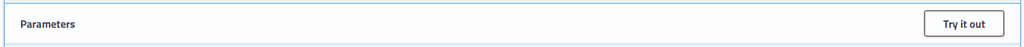

- Entre com os seguintes dados de exemplo:
  - Property_Area = Urban
  - Credit_History = 1
  - Loan_Amount_Term = 5900
  - CoapplicantIncome = 0
  - ApplicantIncome = 360
  - LoanAmount = 4500
  - Education = Graduate
  - Married = No
- Click em Execute:

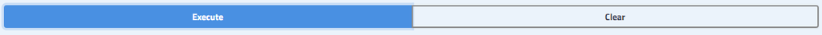

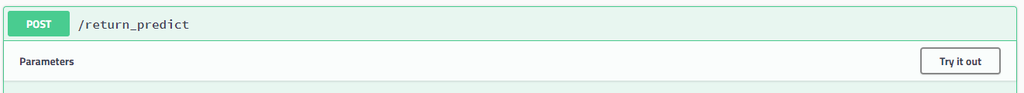

# Aplicação Docker Local

Para rodar a aplicação docker faça o seguinte:

- Em seu computador crie uma pasta com nome tmp em:
  - $\text{C:\Users\UserName>kmdir tmp}$
  - Copie o conteúdo da pasta **aplicacao_docker** para a pasta tmp
  - Via prompt excute a seguinte linha de commando:
    - $\text{C:\Users\UserName>cd tmp}$
    - $\text{C:\Users\UserName\tmp>docker build -t credit_risk .}$
    - Após digitar o comando acima aguarde a instalação dos requisitos em seu sistema.
    - Uma fez finalizada a instalação digite:
    - $\text{C:\Users\UserName\tmp>docker run --rm -p 8000:8000 credit_risk}$